# m6a Xu reanalysis

## m6a reanalysis - Xu METTL3 dataset

The following analysis is the summary of the differential expression analysis performed for the [Xu et al.](https://doi.org/10.1038/s41586-021-03210-1) dataset. In the first instance, the transcriptomic dataset, which formed a subset of the many datasets in this publication, was downloaded from NCBI SRA with project ID PRJNA521368. Total QC, preprocessing and quantification was done using the [NF-core](http://nf-co.re) RNAseq pipeline. Salmon counts obtained from the pipeline were used for subsequent differential expression (DE) analysis using DESeq2 using custom R script.

### Preprocess prior to DE analysis

We first list the files quantified by salmon and using the `tximport` package, import in the workspace. Meanwhile, to determine gene-level counts, we also generate a transcript <–> gene map from the Ensembl mouse annotation package.

```r
library(tximport)
library(DESeq2)
library(data.table)
library(dplyr)
library(tibble)
library(EnsDb.Mmusculus.v79)
library(GEOquery)
library(DT)
library(ggpubr)
library(ggplot2)

# List count files
xu_cnt_files = list.files('/home/ssamberkar/work/projects/results/salmon', pattern = 'quant.sf', full.names = T, recursive = T)

# Generate tx-gene map for mouse from Ensembl Bioconductor

edb = EnsDb.Mmusculus.v79
mm_tx2gene = transcriptsBy(edb, by = "gene", filter = SeqNameFilter(c("X", "Y"))) %>%
  data.frame() %>%
  dplyr::select('tx_name','gene_id')
colnames(mm_tx2gene) = c('TXNAME', 'GENEID')
xu_txi = tximport(xu_cnt_files, type = 'salmon',tx2gene = mm_tx2gene, ignoreTxVersion = T)
```

## DE analysis

### DE results

Since there are more than 1 `genotype` tested in this dataset, we generate separate DE tables for each pairwise contrast:

```r
# Generate all pairwise contrasts from exp. design matrix
xu_contrasts_pairs = t(combn(unique(xu_coldata$genotype),2))
xu_DE_results.list = xu_DE_results_df.list = vector(mode = 'list', length = dim(xu_contrasts_pairs)[1])
names(xu_DE_results.list) = names(xu_DE_results_df.list) = paste(xu_contrasts_pairs[,1], xu_contrasts_pairs[,2], sep = ' ~ ')

for(i in 1:dim(xu_contrasts_pairs)[1]){

  xu_DE_results.list[[i]] = results(xu_dds, contrast = c('genotype', xu_contrasts_pairs[i,1], xu_contrasts_pairs[i,2]))
  xu_DE_results_df.list[[i]] = xu_DE_results.list[[i]] %>%
    data.frame() %>%
    rownames_to_column('GeneID') %>%
    dplyr::filter(padj <= 0.05 & abs(log2FoldChange) >= 1) %>%
    mutate(`-log10_pval` = round(-log10(pvalue),digits = 3),
           `-log10_adj_pval` = round(-log10(padj),digits = 3),
           `log2FC` = round(log2FoldChange,digits = 3),
           `stat` = round(stat, digits = 3),
           `lfcSE` = round(lfcSE, digits = 3),
           `BaseMean` = round(baseMean, digits = 3)) %>%
    dplyr::select(c('GeneID', 'BaseMean', 'log2FC', 'lfcSE', 'stat', '-log10_pval', '-log10_adj_pval'))

  datatable(data.frame(number_of_DEGs = unlist(lapply(xu_DE_results_df.list, function(x)dim(x)[1]))) %>% rownames_to_column('Contrasts'), caption = 'Summary of DEGs for all pairwise contrasts')


}
```

#### DE genes

The individual DE genes table are as follows:

```r
datatable(xu_DE_results_df.list[[1]], caption = paste(names(xu_DE_results_df.list)[1], 'DEG summary'))
```

|  | GeneID | BaseMean | log2FC | lfcSE | stat | -log10_pval | -log10_adj_pval |
| --- | --- | --- | --- | --- | --- | --- | --- |
| 1 | ENSMUSG00000002014 | 179.801 | -1.249 | 0.26 | -4.81 | 5.821 | 4.41 |
| 2 | ENSMUSG00000008035 | 92.732 | -2.531 | 0.446 | -5.681 | 7.874 | 6.162 |
| 3 | ENSMUSG00000015289 | 116.778 | 1.079 | 0.333 | 3.24 | 2.922 | 1.864 |
| 4 | ENSMUSG00000025529 | 26.758 | 3.162 | 0.69 | 4.583 | 5.34 | 3.97 |
| 5 | ENSMUSG00000031012 | 135.971 | 1.119 | 0.348 | 3.213 | 2.882 | 1.842 |
| 6 | ENSMUSG00000031153 | 114.155 | -1.352 | 0.372 | -3.636 | 3.558 | 2.338 |
| 7 | ENSMUSG00000031216 | 119.667 | 1.742 | 0.326 | 5.342 | 7.036 | 5.5 |
| 8 | ENSMUSG00000031371 | 116.042 | -1.025 | 0.32 | -3.201 | 2.863 | 1.833 |
| 9 | ENSMUSG00000033436 | 171.31 | -1.147 | 0.268 | -4.283 | 4.735 | 3.438 |
| 10 | ENSMUSG00000034607 | 37.246 | 4.412 | 0.775 | 5.693 | 7.903 | 6.162 |

[output cut: 18 more lines]

```r
datatable(xu_DE_results_df.list[[2]], caption = paste(names(xu_DE_results_df.list)[2], 'DEG summary'))
```

|  | GeneID | BaseMean | log2FC | lfcSE | stat | -log10_pval | -log10_adj_pval |
| --- | --- | --- | --- | --- | --- | --- | --- |
| 1 | ENSMUSG00000000266 | 4.907 | -5.077 | 2.1 | -2.418 | 1.806 | 1.316 |
| 2 | ENSMUSG00000001131 | 73.689 | -1.1 | 0.375 | -2.935 | 2.477 | 1.886 |
| 3 | ENSMUSG00000001134 | 67.807 | -1.97 | 0.407 | -4.845 | 5.897 | 4.963 |
| 4 | ENSMUSG00000002006 | 497.297 | -1.174 | 0.169 | -6.938 | 11.401 | 10.173 |
| 5 | ENSMUSG00000006200 | 38.942 | -3.03 | 0.6 | -5.05 | 6.355 | 5.37 |
| 6 | ENSMUSG00000008035 | 92.732 | -3.439 | 0.432 | -7.968 | 14.792 | 13.406 |
| 7 | ENSMUSG00000008682 | 1731.974 | -1.566 | 0.324 | -4.838 | 5.882 | 4.961 |
| 8 | ENSMUSG00000009406 | 162.169 | -1.039 | 0.26 | -4 | 4.198 | 3.4 |
| 9 | ENSMUSG00000015291 | 415.562 | -1.336 | 0.203 | -6.574 | 10.311 | 9.106 |
| 10 | ENSMUSG00000016150 | 9.7 | 4.978 | 1.424 | 3.497 | 3.327 | 2.625 |

[output cut: 105 more lines]

```r
datatable(xu_DE_results_df.list[[3]], caption = paste(names(xu_DE_results_df.list)[3], 'DEG summary'))
```

|  | GeneID | BaseMean | log2FC | lfcSE | stat | -log10_pval | -log10_adj_pval |
| --- | --- | --- | --- | --- | --- | --- | --- |
| 1 | ENSMUSG00000008035 | 92.732 | -1.549 | 0.452 | -3.429 | 3.217 | 2.027 |
| 2 | ENSMUSG00000025529 | 26.758 | 2.395 | 0.659 | 3.636 | 3.558 | 2.294 |
| 3 | ENSMUSG00000031012 | 135.971 | 1.095 | 0.345 | 3.176 | 2.826 | 1.744 |
| 4 | ENSMUSG00000031103 | 144.846 | 1.153 | 0.292 | 3.945 | 4.098 | 2.681 |
| 5 | ENSMUSG00000031209 | 9.174 | 5.421 | 1.821 | 2.977 | 2.536 | 1.512 |
| 6 | ENSMUSG00000031216 | 119.667 | 2.075 | 0.337 | 6.154 | 9.123 | 7.126 |
| 7 | ENSMUSG00000031371 | 116.042 | -1.087 | 0.32 | -3.398 | 3.168 | 2.016 |
| 8 | ENSMUSG00000031438 | 49.935 | 1.723 | 0.509 | 3.388 | 3.152 | 2.013 |
| 9 | ENSMUSG00000034607 | 37.246 | 2.684 | 0.601 | 4.464 | 5.094 | 3.575 |
| 10 | ENSMUSG00000036782 | 1491.332 | 1.922 | 0.12 | 16.07 | 57.379 | 54.684 |

[output cut: 13 more lines]

```r
datatable(xu_DE_results_df.list[[4]], caption = paste(names(xu_DE_results_df.list)[4], 'DEG summary'))
```

|  | GeneID | BaseMean | log2FC | lfcSE | stat | -log10_pval | -log10_adj_pval |
| --- | --- | --- | --- | --- | --- | --- | --- |
| 1 | ENSMUSG00000000134 | 303.779 | -1.377 | 0.234 | -5.894 | 8.423 | 7.403 |
| 2 | ENSMUSG00000001131 | 73.689 | -1.408 | 0.379 | -3.711 | 3.686 | 2.998 |
| 3 | ENSMUSG00000001134 | 67.807 | -1.525 | 0.399 | -3.826 | 3.885 | 3.187 |
| 4 | ENSMUSG00000001986 | 10.452 | -3.362 | 1.116 | -3.012 | 2.586 | 2.036 |
| 5 | ENSMUSG00000002006 | 497.297 | -2.014 | 0.174 | -11.548 | 30.122 | 28.227 |
| 6 | ENSMUSG00000006200 | 38.942 | -2.186 | 0.56 | -3.905 | 4.025 | 3.317 |
| 7 | ENSMUSG00000006423 | 161.917 | 1.041 | 0.297 | 3.507 | 3.343 | 2.682 |
| 8 | ENSMUSG00000006678 | 733.587 | 1.445 | 0.153 | 9.435 | 20.406 | 18.863 |
| 9 | ENSMUSG00000009731 | 26.736 | -2.933 | 0.713 | -4.116 | 4.414 | 3.688 |
| 10 | ENSMUSG00000015289 | 116.778 | -2.066 | 0.321 | -6.431 | 9.897 | 8.771 |

[output cut: 149 more lines]

```r
datatable(xu_DE_results_df.list[[5]], caption = paste(names(xu_DE_results_df.list)[5], 'DEG summary'))
```

|  | GeneID | BaseMean | log2FC | lfcSE | stat | -log10_pval | -log10_adj_pval |
| --- | --- | --- | --- | --- | --- | --- | --- |
| 1 | ENSMUSG00000036959 | 211.71 | 1.436 | 0.278 | 5.165 | 6.618 | 4.521 |

```r
datatable(xu_DE_results_df.list[[6]], caption = paste(names(xu_DE_results_df.list)[6], 'DEG summary'))
```

|  | GeneID | BaseMean | log2FC | lfcSE | stat | -log10_pval | -log10_adj_pval |
| --- | --- | --- | --- | --- | --- | --- | --- |
| 1 | ENSMUSG00000000134 | 303.779 | 1.287 | 0.236 | 5.455 | 7.311 | 6.371 |
| 2 | ENSMUSG00000000881 | 183.036 | 1.04 | 0.256 | 4.068 | 4.324 | 3.612 |
| 3 | ENSMUSG00000001134 | 67.807 | 1.465 | 0.402 | 3.645 | 3.572 | 2.914 |
| 4 | ENSMUSG00000002006 | 497.297 | 1.842 | 0.173 | 10.623 | 25.634 | 23.915 |
| 5 | ENSMUSG00000002012 | 10.686 | 2.773 | 1.162 | 2.387 | 1.769 | 1.357 |
| 6 | ENSMUSG00000004317 | 113.628 | 1.164 | 0.359 | 3.244 | 2.929 | 2.364 |
| 7 | ENSMUSG00000006200 | 38.942 | 2.318 | 0.566 | 4.092 | 4.37 | 3.643 |
| 8 | ENSMUSG00000006423 | 161.917 | -1.135 | 0.297 | -3.818 | 3.872 | 3.185 |
| 9 | ENSMUSG00000006678 | 733.587 | -1.29 | 0.154 | -8.402 | 16.358 | 14.992 |
| 10 | ENSMUSG00000008035 | 92.732 | 1.889 | 0.4 | 4.719 | 5.625 | 4.8 |

[output cut: 158 more lines]

### MA plots

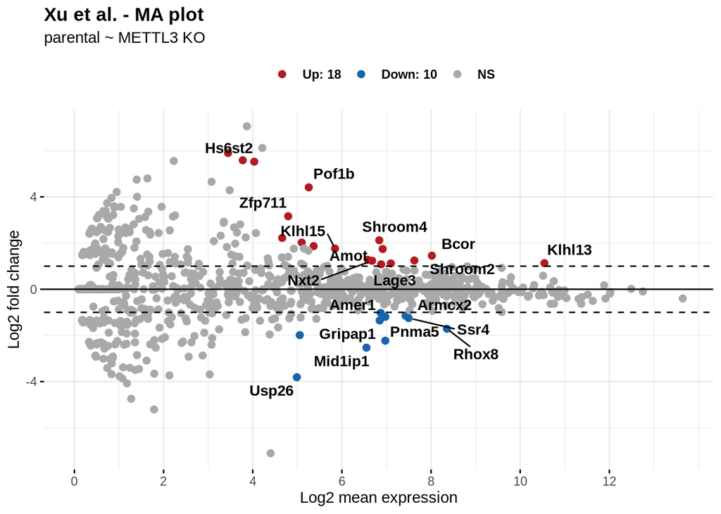

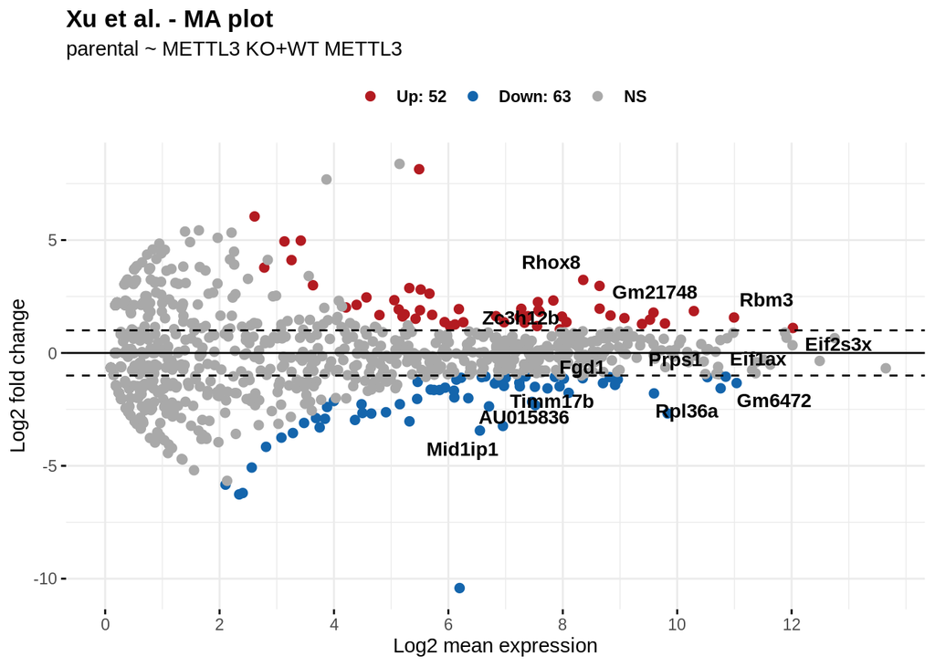

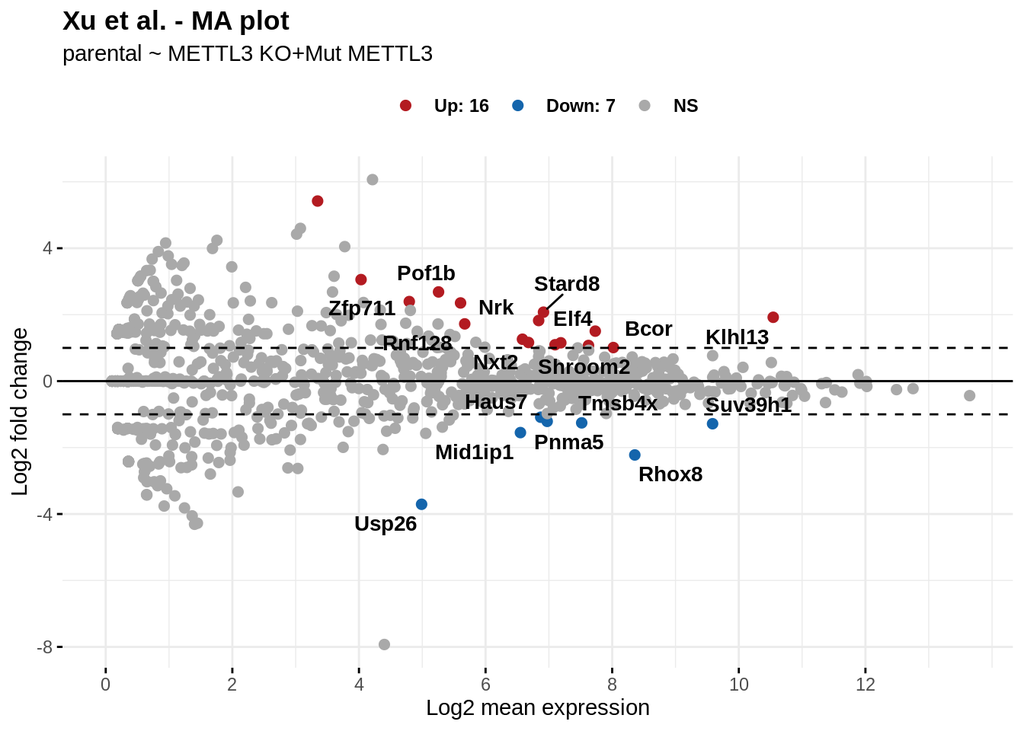

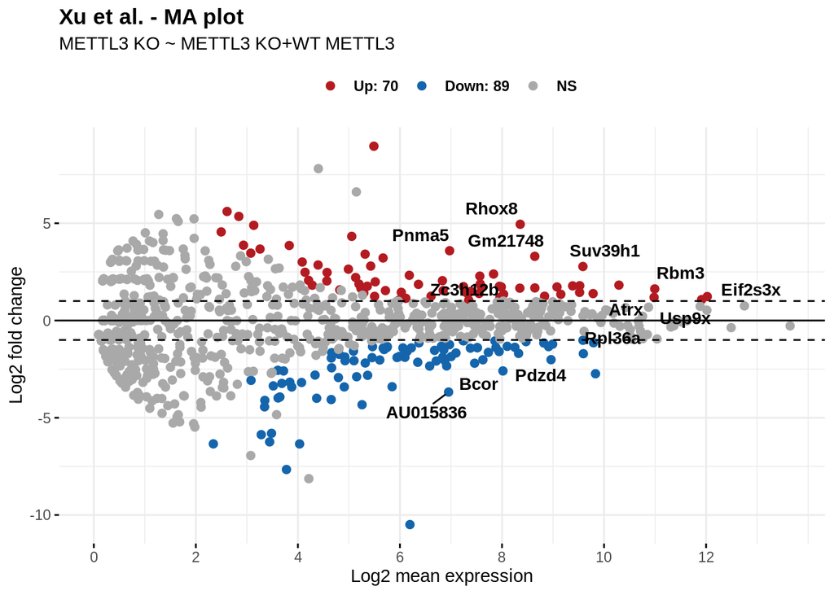

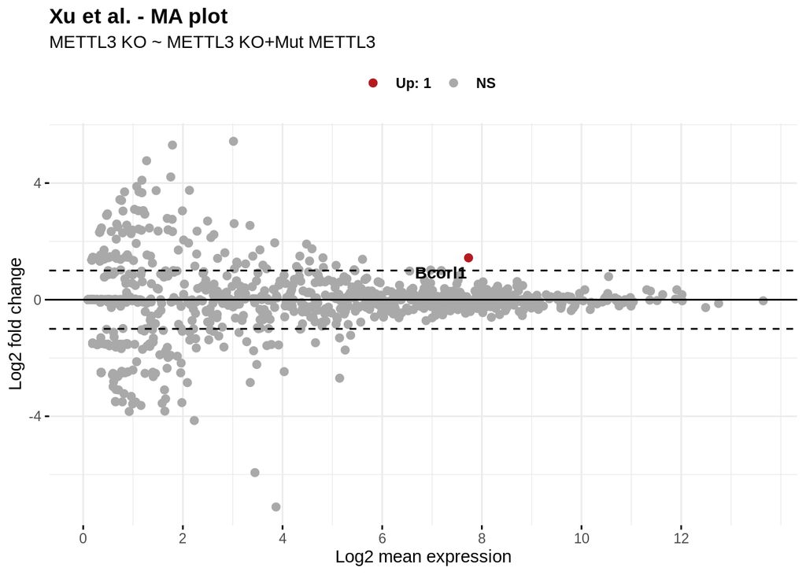

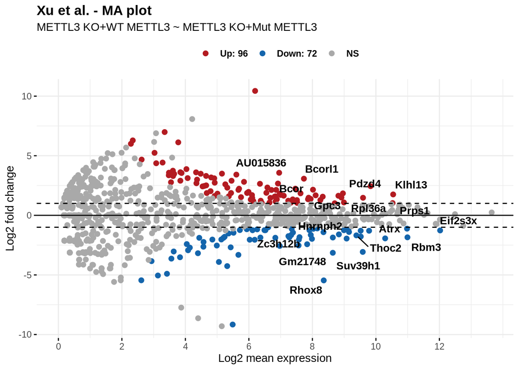

```r
# Plot MA for all contrasts

xu_ma_plots.list = vector(mode = 'list', length = length(xu_DE_results.list))
names(xu_ma_plots.list) = names(xu_DE_results.list)

for (i in 1:length(xu_ma_plots.list)){

  res = results(xu_dds, contrast = c('genotype', xu_contrasts_pairs[i,1], xu_contrasts_pairs[i,2])) %>% data.frame()
  mm_symbol = ensembldb::select(x = edb, keys = rownames(res), columns = 'SYMBOL', keytype = 'GENEID')
  res$name = mm_symbol$SYMBOL
  res$detection_call = 0
  res$detection_call[abs(res$log2FoldChange) > 1 & res$padj <= 0.05] = 1
  res = res %>% dplyr::select(c('name', 'baseMean', 'log2FoldChange', 'padj', 'detection_call'))

  xu_ma_plots.list[[i]] = ggmaplot(res, fdr = 0.05, fc = 2, size = 2,
           palette = c("#B31B21", "#1465AC", "darkgray"),
           genenames = as.vector(res$name),
           legend = "top", top = 20,
           font.label = c("bold", 11),
           font.legend = "bold",
           font.main = "bold",
           ggtheme = ggplot2::theme_minimal()) +
    ggtitle(label = 'Xu et al. - MA plot', subtitle = paste(xu_contrasts_pairs[i,1] ,'~', xu_contrasts_pairs[i,2], sep = ' '))


}

for (i in 1:length(xu_ma_plots.list)){
  plot(xu_ma_plots.list[[i]])
}
```

### PCA plots

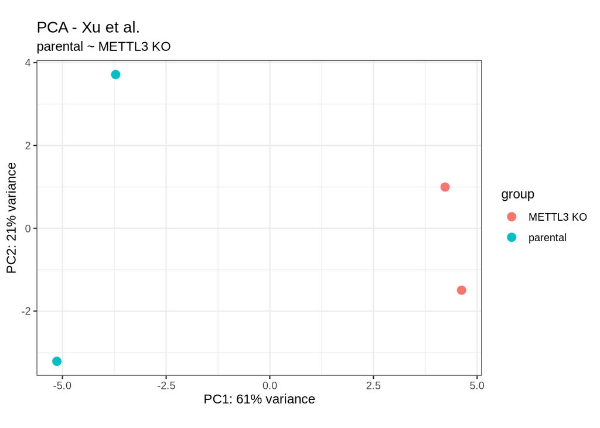

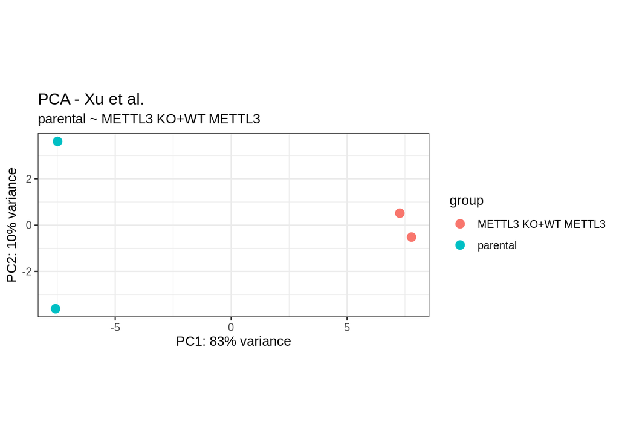

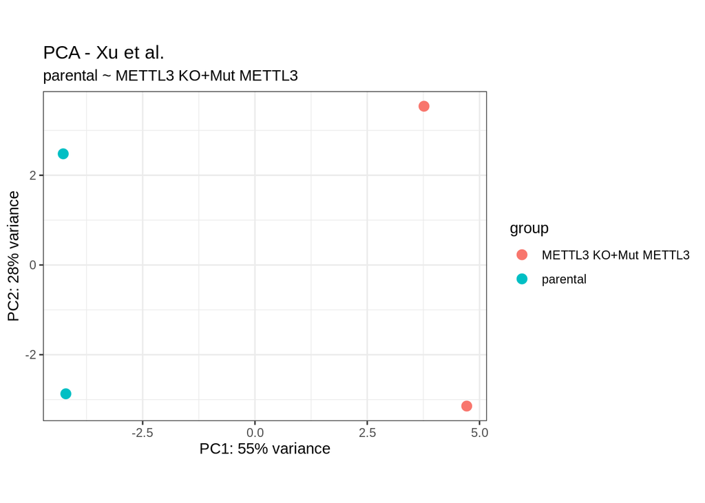

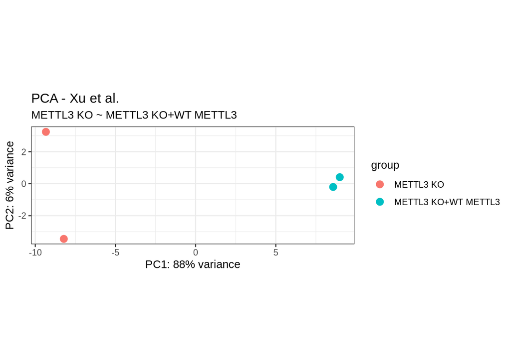

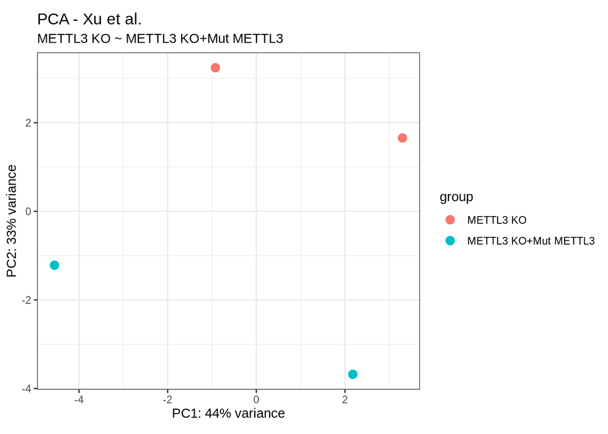

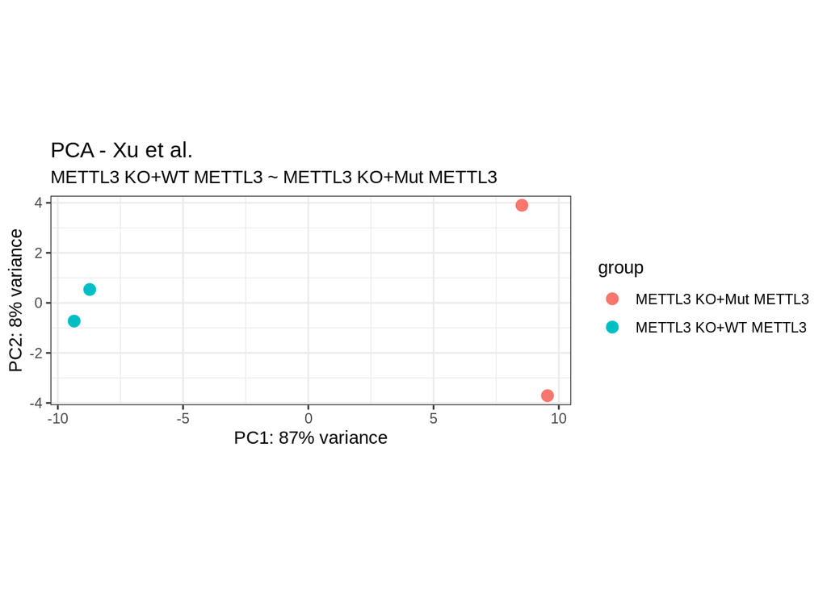

```r
xu_pca_plots.list = vector(mode = 'list', length = length(xu_DE_results.list))
names(xu_pca_plots.list) = names(xu_DE_results.list)

# Applying rlog transform as number of samples < 30

xu_rlog_counts = rlogTransformation(xu_dds)

for(i in 1:length(xu_pca_plots.list)) {

  xu_pca_plots.list[[i]] = plotPCA(xu_rlog_counts[,which(xu_rlog_counts$genotype %in% c(xu_contrasts_pairs[i,1], xu_contrasts_pairs[i,2]))], intgroup = c('genotype')) +
  theme_bw() +
  ggtitle(label = 'PCA - Xu et al.', subtitle = paste(xu_contrasts_pairs[i,1], '~', xu_contrasts_pairs[i,2], sep=' '))

}

for (i in 1:length(xu_ma_plots.list)){
  plot(xu_pca_plots.list[[i]])
}
```